# 002 incidence

Katie Gostic

11/1/2017

Notes on data formatting from Deborah Wentworth:

- symdur is symptom duration (days) prior to enrollment
- date info is for enrollment date
- fluvac6 and fluvac12 are flu vaccination in last 6 or last 12 months
- anyvac combines values from fluvac6 and fluvac12, whichever was collected for a given patient is reported.
- anyav is use of antivirals at any time
- anydx is any diagnosis in the medical history section
- flutype is subtype: 1=H1N1, 2=H3N2, 3=flu B, 4=PCR negative, 5=Inf A, subtype unknown, and 6=coinfection with multiple strains
- resolved is symptom resolution within 14 days
- country code is the 3 letter code for country of enrollment - think the abbreviations will be obvious

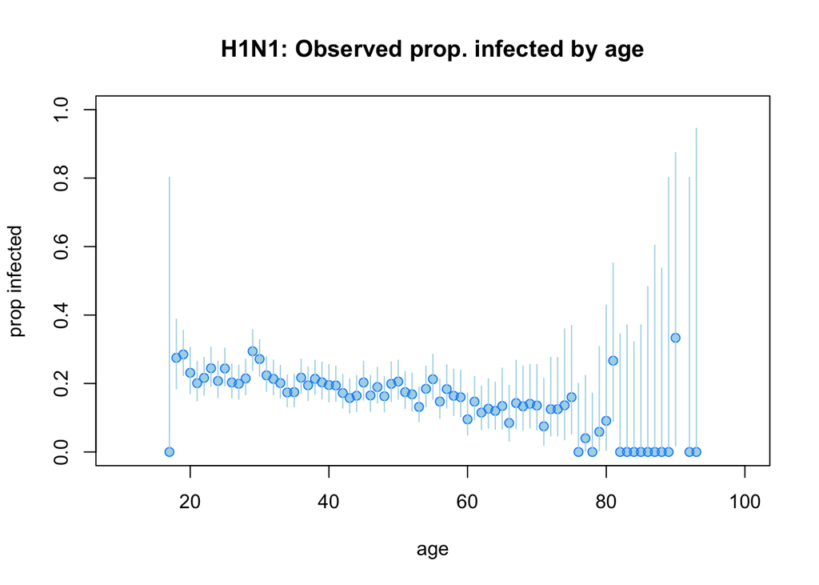

#### Visualize the relationship between age and prob of H3N2 infection

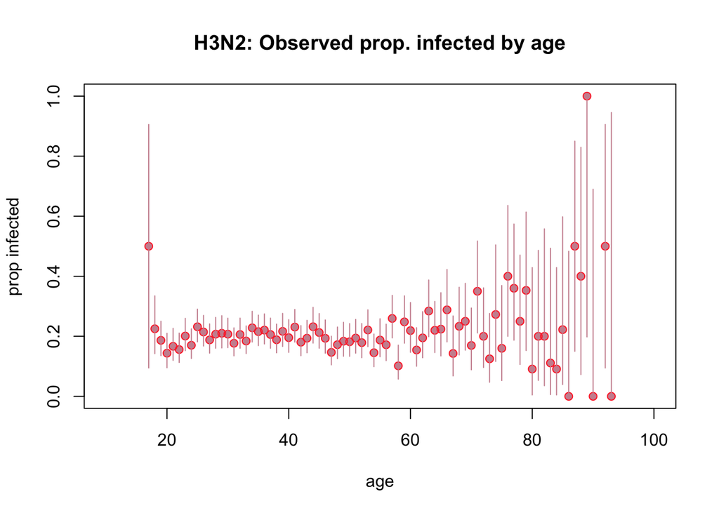

#### Visualize the relationship between country and prob infection

H1N1

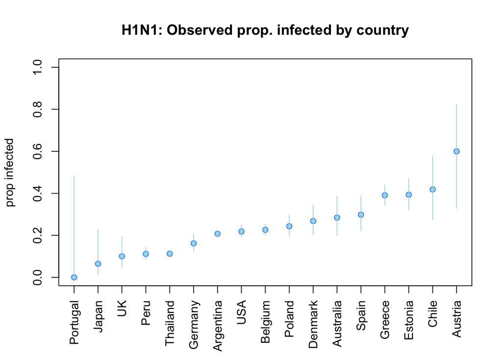

H3N2

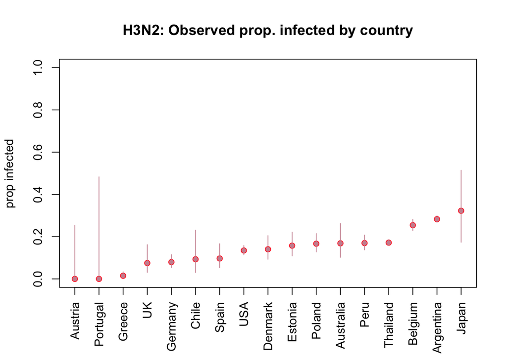

#### Visualize the relationship between season and prob infection

H1N1

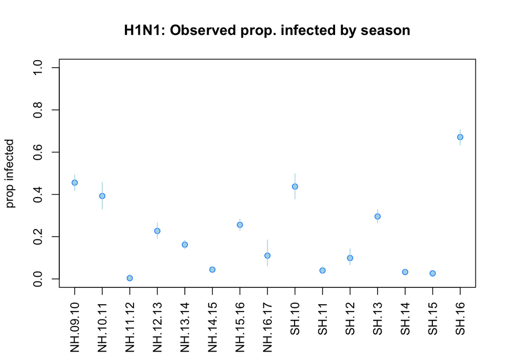

H3N2

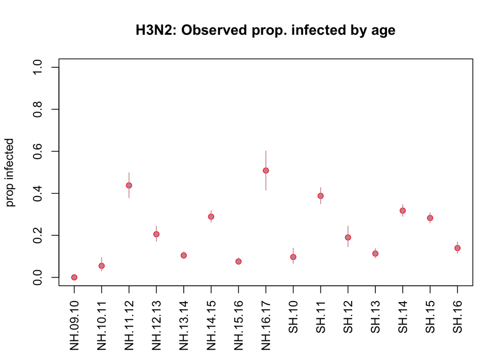

- age
- imprinting status
- vaccination status
- antiviral use
- season
- country

### Clean data for fitting

```
##
## Argentina Australia   Austria   Belgium     Chile   Denmark   Estonia
##      3175        95        15      1100        43       164       178
##   Germany    Greece     Japan      Peru    Poland  Portugal     Spain
##       340       401        31       466       300         6       124
##  Thailand        UK       USA
##      3030        80       944
```

```
## [1] 10492
```

### First fit a model where the only independent variable is age

Treat vaccination, antivial use, underlying symptoms, country and season as blocking variables with fixed effects

```r
library(splines)
library(ROCR)
```

```r
## Fit to country, season and medical history only (no effect of age or imprinting)
fit0 = glm(infected ~ anyav + anydx + country + season + challenge*anyvac, data = train, family = binomial)
summary(fit0)
```

```
##
## Call:
## glm(formula = infected ~ anyav + anydx + country + season + challenge *
##     anyvac, family = binomial, data = train)
##
## Deviance Residuals:
##     Min       1Q   Median       3Q      Max
## -2.3243  -0.9423  -0.6654   1.2077   2.2377
##
## Coefficients:
##                       Estimate Std. Error z value Pr(>|z|)
## (Intercept)            0.66821    0.13699   4.878 1.07e-06 ***
## anyav1                 0.91405    0.08513  10.737  < 2e-16 ***
## anydx1                -0.20708    0.05074  -4.081 4.48e-05 ***
## countryAustralia      -0.54576    0.24618  -2.217 0.026626 *
## countryBelgium        -0.11227    0.11734  -0.957 0.338662
## countryChile           0.69408    0.34528   2.010 0.044409 *
## countryDenmark        -0.47710    0.19758  -2.415 0.015745 *
## countryEstonia        -0.06345    0.18972  -0.334 0.738038
## countryGermany        -1.15084    0.17255  -6.670 2.56e-11 ***
## countryGreece         -0.57809    0.15445  -3.743 0.000182 ***
## countryJapan          -0.60765    0.41086  -1.479 0.139143
## countryOther          -0.71855    0.48517  -1.481 0.138596
## countryPeru           -1.10629    0.13040  -8.484  < 2e-16 ***
## countryPoland         -0.40631    0.15792  -2.573 0.010086 *
## countrySpain          -0.79532    0.21885  -3.634 0.000279 ***
## countryThailand       -0.94435    0.08166 -11.565  < 2e-16 ***
## countryUK             -1.53728    0.32616  -4.713 2.44e-06 ***
## countryUSA            -0.74694    0.12326  -6.060 1.36e-09 ***
## seasonNH.10.11        -0.26328    0.17304  -1.521 0.128145
## seasonNH.11.12        -0.78771    0.17957  -4.387 1.15e-05 ***
## seasonNH.12.13        -0.48814    0.13913  -3.508 0.000451 ***
## seasonNH.13.14        -0.92297    0.12286  -7.512 5.80e-14 ***
## seasonNH.14.15        -0.91181    0.12820  -7.112 1.14e-12 ***
## seasonNH.15.16        -0.68877    0.11780  -5.847 5.00e-09 ***
## seasonNH.16.17         0.31053    0.23057   1.347 0.178042
## seasonSH.10            0.03190    0.18083   0.176 0.859972
## seasonSH.11           -1.25000    0.16665  -7.501 6.35e-14 ***
## seasonSH.12           -1.29317    0.19540  -6.618 3.64e-11 ***
## seasonSH.13           -0.88686    0.14831  -5.980 2.23e-09 ***
## seasonSH.14           -1.07743    0.14760  -7.299 2.89e-13 ***
## seasonSH.15           -1.23592    0.14562  -8.487  < 2e-16 ***
## seasonSH.16            1.04951    0.16078   6.528 6.69e-11 ***
## challengeH3N2          0.31230    0.06280   4.973 6.59e-07 ***
## anyvac1               -0.69916    0.09226  -7.578 3.51e-14 ***
## anyvac2                0.28320    0.48665   0.582 0.560610
## challengeH3N2:anyvac1  0.36875    0.11841   3.114 0.001845 **
## challengeH3N2:anyvac2  0.11588    0.84879   0.137 0.891409
## ---
## Signif. codes:  0 '***' 0.001 '**' 0.01 '*' 0.05 '.' 0.1 ' ' 1
##
## (Dispersion parameter for binomial family taken to be 1)
##
##     Null deviance: 12674  on 9491  degrees of freedom
## Residual deviance: 11425  on 9455  degrees of freedom
## AIC: 11499
##
## Number of Fisher Scoring iterations: 4
```

```r
## H1N1 fit to age only, plus fixed effects of vaccination, av use, underlying conditions, country and season
fit1 = glm(infected ~ ns(age, knots = 65)+anyav + anydx + country + season + challenge*anyvac, data = train, family = binomial)
summary(fit1)
```

```
##
## Call:
## glm(formula = infected ~ ns(age, knots = 65) + anyav + anydx +
##     country + season + challenge * anyvac, family = binomial,
##     data = train)
##
## Deviance Residuals:
##     Min       1Q   Median       3Q      Max
## -2.3335  -0.9426  -0.6703   1.2074   2.2232
##
## Coefficients:
##                       Estimate Std. Error z value Pr(>|z|)
## (Intercept)            0.63941    0.14216   4.498 6.87e-06 ***
## ns(age, knots = 65)1  -0.10313    0.16495  -0.625 0.531840
## ns(age, knots = 65)2  -0.35947    0.25535  -1.408 0.159198
## anyav1                 0.91635    0.08515  10.762  < 2e-16 ***
## anydx1                -0.19964    0.05300  -3.767 0.000165 ***
## countryAustralia      -0.55677    0.24642  -2.259 0.023856 *
## countryBelgium        -0.11544    0.11776  -0.980 0.326939
## countryChile           0.69065    0.34528   2.000 0.045474 *
## countryDenmark        -0.47939    0.19768  -2.425 0.015303 *
## countryEstonia        -0.06874    0.18976  -0.362 0.717182
## countryGermany        -1.16374    0.17282  -6.734 1.65e-11 ***
## countryGreece         -0.57943    0.15467  -3.746 0.000179 ***
## countryJapan          -0.62665    0.41120  -1.524 0.127523
## countryOther          -0.72171    0.48505  -1.488 0.136774
## countryPeru           -1.11279    0.13049  -8.528  < 2e-16 ***
## countryPoland         -0.40743    0.15794  -2.580 0.009890 **
## countrySpain          -0.78223    0.21896  -3.573 0.000354 ***
## countryThailand       -0.94183    0.08181 -11.512  < 2e-16 ***
## countryUK             -1.53401    0.32635  -4.700 2.60e-06 ***
## countryUSA            -0.74800    0.12338  -6.062 1.34e-09 ***
## seasonNH.10.11        -0.26959    0.17330  -1.556 0.119804
## seasonNH.11.12        -0.78910    0.17992  -4.386 1.15e-05 ***
## seasonNH.12.13        -0.49177    0.13977  -3.518 0.000434 ***
## seasonNH.13.14        -0.92663    0.12352  -7.502 6.31e-14 ***
## seasonNH.14.15        -0.91316    0.12874  -7.093 1.31e-12 ***
## seasonNH.15.16        -0.69103    0.11854  -5.830 5.56e-09 ***
## seasonNH.16.17         0.30628    0.23120   1.325 0.185247
## seasonSH.10            0.03051    0.18087   0.169 0.866049
## seasonSH.11           -1.25083    0.16703  -7.489 6.96e-14 ***
## seasonSH.12           -1.29425    0.19580  -6.610 3.84e-11 ***
## seasonSH.13           -0.89070    0.14883  -5.985 2.17e-09 ***
## seasonSH.14           -1.07900    0.14808  -7.287 3.17e-13 ***
## seasonSH.15           -1.23548    0.14610  -8.456  < 2e-16 ***
## seasonSH.16            1.04920    0.16127   6.506 7.72e-11 ***
## challengeH3N2          0.31250    0.06283   4.974 6.55e-07 ***
## anyvac1               -0.69494    0.09276  -7.492 6.79e-14 ***
## anyvac2                0.27270    0.48698   0.560 0.575498
## challengeH3N2:anyvac1  0.36892    0.11846   3.114 0.001843 **
## challengeH3N2:anyvac2  0.14135    0.84890   0.167 0.867757
## ---
## Signif. codes:  0 '***' 0.001 '**' 0.01 '*' 0.05 '.' 0.1 ' ' 1
##
## (Dispersion parameter for binomial family taken to be 1)
##
##     Null deviance: 12674  on 9491  degrees of freedom
## Residual deviance: 11423  on 9453  degrees of freedom
## AIC: 11501
##
## Number of Fisher Scoring iterations: 4
```

```r
## H1N1 fit to age plus imprinting, plus fixed effects of vaccination, av use, underlying conditions, country and season
fit2 = glm(infected ~ ns(age, knots = 65)+protected_grp + anyav + anydx + country + season + challenge*anyvac , data = train, family = binomial)
summary(fit2)
```

```
##
## Call:
## glm(formula = infected ~ ns(age, knots = 65) + protected_grp +
##     anyav + anydx + country + season + challenge * anyvac, family = binomial,
##     data = train)
##
## Deviance Residuals:
##     Min       1Q   Median       3Q      Max
## -2.3501  -0.9482  -0.6720   1.2051   2.2385
##
## Coefficients:
##                       Estimate Std. Error z value Pr(>|z|)
## (Intercept)            0.68036    0.14458   4.706 2.53e-06 ***
## ns(age, knots = 65)1  -0.13250    0.16613  -0.798 0.425092
## ns(age, knots = 65)2  -0.40269    0.25724  -1.565 0.117484
## protected_grp         -0.10270    0.06514  -1.577 0.114892
## anyav1                 0.91921    0.08517  10.792  < 2e-16 ***
## anydx1                -0.20037    0.05301  -3.780 0.000157 ***
## countryAustralia      -0.54881    0.24637  -2.228 0.025906 *
## countryBelgium        -0.11312    0.11778  -0.960 0.336846
## countryChile           0.69366    0.34527   2.009 0.044536 *
## countryDenmark        -0.47361    0.19773  -2.395 0.016609 *
## countryEstonia        -0.07214    0.18976  -0.380 0.703815
## countryGermany        -1.16164    0.17282  -6.722 1.80e-11 ***
## countryGreece         -0.57506    0.15478  -3.715 0.000203 ***
## countryJapan          -0.61948    0.41078  -1.508 0.131539
## countryOther          -0.73249    0.48517  -1.510 0.131099
## countryPeru           -1.11488    0.13045  -8.546  < 2e-16 ***
## countryPoland         -0.40315    0.15799  -2.552 0.010721 *
## countrySpain          -0.77125    0.21883  -3.524 0.000424 ***
## countryThailand       -0.94222    0.08182 -11.516  < 2e-16 ***
## countryUK             -1.53611    0.32623  -4.709 2.49e-06 ***
## countryUSA            -0.74830    0.12341  -6.064 1.33e-09 ***
## seasonNH.10.11        -0.26258    0.17343  -1.514 0.130026
## seasonNH.11.12        -0.78634    0.17994  -4.370 1.24e-05 ***
## seasonNH.12.13        -0.48746    0.13981  -3.487 0.000489 ***
## seasonNH.13.14        -0.92200    0.12361  -7.459 8.70e-14 ***
## seasonNH.14.15        -0.90360    0.12891  -7.009 2.40e-12 ***
## seasonNH.15.16        -0.68770    0.11859  -5.799 6.68e-09 ***
## seasonNH.16.17         0.30549    0.23110   1.322 0.186208
## seasonSH.10            0.03174    0.18085   0.175 0.860693
## seasonSH.11           -1.24447    0.16711  -7.447 9.53e-14 ***
## seasonSH.12           -1.28497    0.19590  -6.559 5.40e-11 ***
## seasonSH.13           -0.88253    0.14895  -5.925 3.12e-09 ***
## seasonSH.14           -1.06707    0.14831  -7.195 6.26e-13 ***
## seasonSH.15           -1.22768    0.14620  -8.397  < 2e-16 ***
## seasonSH.16            1.05488    0.16140   6.536 6.32e-11 ***
## challengeH3N2          0.32148    0.06312   5.093 3.52e-07 ***
## anyvac1               -0.68219    0.09312  -7.326 2.37e-13 ***
## anyvac2                0.28030    0.48764   0.575 0.565419
## challengeH3N2:anyvac1  0.34910    0.11914   2.930 0.003387 **
## challengeH3N2:anyvac2  0.12407    0.84860   0.146 0.883756
## ---
## Signif. codes:  0 '***' 0.001 '**' 0.01 '*' 0.05 '.' 0.1 ' ' 1
##
## (Dispersion parameter for binomial family taken to be 1)
##
##     Null deviance: 12674  on 9491  degrees of freedom
## Residual deviance: 11421  on 9452  degrees of freedom
## AIC: 11501
##
## Number of Fisher Scoring iterations: 4
```

```r
# Add imprinting at H.subtype level
fit3 = glm(infected ~ ns(age, knots = 65)+protected_sub + anyav + anydx + country + season + challenge*anyvac , data = train, family = binomial)
summary(fit3)
```

```
##
## Call:
## glm(formula = infected ~ ns(age, knots = 65) + protected_sub +
##     anyav + anydx + country + season + challenge * anyvac, family = binomial,
##     data = train)
##
## Deviance Residuals:
##     Min       1Q   Median       3Q      Max
## -2.3464  -0.9494  -0.6769   1.2044   2.2719
##
## Coefficients:
##                       Estimate Std. Error z value Pr(>|z|)
## (Intercept)            0.71938    0.14660   4.907 9.24e-07 ***
## ns(age, knots = 65)1  -0.23892    0.17615  -1.356 0.174976
## ns(age, knots = 65)2  -0.37984    0.25633  -1.482 0.138392
## protected_sub         -0.17224    0.07652  -2.251 0.024387 *
## anyav1                 0.91819    0.08514  10.785  < 2e-16 ***
## anydx1                -0.19876    0.05302  -3.749 0.000178 ***
## countryAustralia      -0.55005    0.24625  -2.234 0.025504 *
## countryBelgium        -0.11657    0.11779  -0.990 0.322350
## countryChile           0.69070    0.34550   1.999 0.045590 *
## countryDenmark        -0.47623    0.19769  -2.409 0.015999 *
## countryEstonia        -0.06787    0.18977  -0.358 0.720609
## countryGermany        -1.17165    0.17291  -6.776 1.23e-11 ***
## countryGreece         -0.57423    0.15481  -3.709 0.000208 ***
## countryJapan          -0.60960    0.41058  -1.485 0.137615
## countryOther          -0.73198    0.48514  -1.509 0.131349
## countryPeru           -1.11969    0.13048  -8.581  < 2e-16 ***
## countryPoland         -0.40008    0.15805  -2.531 0.011360 *
## countrySpain          -0.76410    0.21889  -3.491 0.000482 ***
## countryThailand       -0.94269    0.08184 -11.519  < 2e-16 ***
## countryUK             -1.53925    0.32631  -4.717 2.39e-06 ***
## countryUSA            -0.75486    0.12344  -6.115 9.65e-10 ***
## seasonNH.10.11        -0.27231    0.17338  -1.571 0.116269
## seasonNH.11.12        -0.78368    0.17995  -4.355 1.33e-05 ***
## seasonNH.12.13        -0.48516    0.13985  -3.469 0.000522 ***
## seasonNH.13.14        -0.92115    0.12363  -7.451 9.29e-14 ***
## seasonNH.14.15        -0.89832    0.12895  -6.966 3.26e-12 ***
## seasonNH.15.16        -0.68680    0.11861  -5.790 7.03e-09 ***
## seasonNH.16.17         0.30820    0.23111   1.334 0.182333
## seasonSH.10            0.02901    0.18084   0.160 0.872569
## seasonSH.11           -1.24746    0.16708  -7.466 8.25e-14 ***
## seasonSH.12           -1.27920    0.19593  -6.529 6.62e-11 ***
## seasonSH.13           -0.88160    0.14893  -5.920 3.22e-09 ***
## seasonSH.14           -1.06725    0.14823  -7.200 6.03e-13 ***
## seasonSH.15           -1.22698    0.14619  -8.393  < 2e-16 ***
## seasonSH.16            1.05988    0.16146   6.564 5.22e-11 ***
## challengeH3N2          0.35995    0.06637   5.424 5.84e-08 ***
## anyvac1               -0.67805    0.09310  -7.283 3.27e-13 ***
## anyvac2                0.26418    0.48716   0.542 0.587623
## challengeH3N2:anyvac1  0.34511    0.11897   2.901 0.003724 **
## challengeH3N2:anyvac2  0.13406    0.84815   0.158 0.874410
## ---
## Signif. codes:  0 '***' 0.001 '**' 0.01 '*' 0.05 '.' 0.1 ' ' 1
##
## (Dispersion parameter for binomial family taken to be 1)
##
##     Null deviance: 12674  on 9491  degrees of freedom
## Residual deviance: 11418  on 9452  degrees of freedom
## AIC: 11498
##
## Number of Fisher Scoring iterations: 4
```

```r
# Add imprinting at N.subtype level
fit4 = glm(infected ~ protected_N + anyav + anydx + country + season + challenge*anyvac + ns(age, knots = 65), data = train, family = binomial)
summary(fit4)
```

```
##
## Call:
## glm(formula = infected ~ protected_N + anyav + anydx + country +
##     season + challenge * anyvac + ns(age, knots = 65), family = binomial,
##     data = train)
##
## Deviance Residuals:
##     Min       1Q   Median       3Q      Max
## -2.3627  -0.9545  -0.6763   1.1984   2.3225
##
## Coefficients:
##                       Estimate Std. Error z value Pr(>|z|)
## (Intercept)            0.71144    0.14363   4.953 7.29e-07 ***
## protected_N           -0.30021    0.08143  -3.687 0.000227 ***
## anyav1                 0.91365    0.08514  10.732  < 2e-16 ***
## anydx1                -0.19723    0.05305  -3.718 0.000201 ***
## countryAustralia      -0.55362    0.24650  -2.246 0.024707 *
## countryBelgium        -0.11341    0.11786  -0.962 0.335910
## countryChile           0.69436    0.34600   2.007 0.044768 *
## countryDenmark        -0.47593    0.19784  -2.406 0.016143 *
## countryEstonia        -0.07258    0.18996  -0.382 0.702395
## countryGermany        -1.17304    0.17305  -6.779 1.21e-11 ***
## countryGreece         -0.57082    0.15496  -3.684 0.000230 ***
## countryJapan          -0.59083    0.41094  -1.438 0.150505
## countryOther          -0.72292    0.48514  -1.490 0.136191
## countryPeru           -1.11324    0.13050  -8.530  < 2e-16 ***
## countryPoland         -0.39393    0.15818  -2.490 0.012759 *
## countrySpain          -0.76151    0.21902  -3.477 0.000507 ***
## countryThailand       -0.93851    0.08188 -11.462  < 2e-16 ***
## countryUK             -1.53962    0.32631  -4.718 2.38e-06 ***
## countryUSA            -0.74269    0.12341  -6.018 1.77e-09 ***
## seasonNH.10.11        -0.28719    0.17340  -1.656 0.097665 .
## seasonNH.11.12        -0.79691    0.17996  -4.428 9.50e-06 ***
## seasonNH.12.13        -0.49803    0.13994  -3.559 0.000372 ***
## seasonNH.13.14        -0.93554    0.12370  -7.563 3.95e-14 ***
## seasonNH.14.15        -0.91017    0.12885  -7.064 1.62e-12 ***
## seasonNH.15.16        -0.70586    0.11876  -5.944 2.78e-09 ***
## seasonNH.16.17         0.30886    0.23141   1.335 0.181969
## seasonSH.10            0.03207    0.18092   0.177 0.859317
## seasonSH.11           -1.25749    0.16719  -7.521 5.43e-14 ***
## seasonSH.12           -1.28186    0.19602  -6.539 6.18e-11 ***
## seasonSH.13           -0.88596    0.14892  -5.949 2.69e-09 ***
## seasonSH.14           -1.07925    0.14827  -7.279 3.36e-13 ***
## seasonSH.15           -1.24042    0.14623  -8.482  < 2e-16 ***
## seasonSH.16            1.05870    0.16152   6.554 5.58e-11 ***
## challengeH3N2          0.45186    0.07359   6.141 8.22e-10 ***
## anyvac1               -0.68140    0.09297  -7.329 2.32e-13 ***
## anyvac2                0.23290    0.48690   0.478 0.632420
## ns(age, knots = 65)1  -0.17795    0.16685  -1.066 0.286203
## ns(age, knots = 65)2  -0.53739    0.26225  -2.049 0.040451 *
## challengeH3N2:anyvac1  0.34695    0.11874   2.922 0.003480 **
## challengeH3N2:anyvac2  0.17531    0.85032   0.206 0.836655
## ---
## Signif. codes:  0 '***' 0.001 '**' 0.01 '*' 0.05 '.' 0.1 ' ' 1
##
## (Dispersion parameter for binomial family taken to be 1)
##
##     Null deviance: 12674  on 9491  degrees of freedom
## Residual deviance: 11409  on 9452  degrees of freedom
## AIC: 11489
##
## Number of Fisher Scoring iterations: 4
```

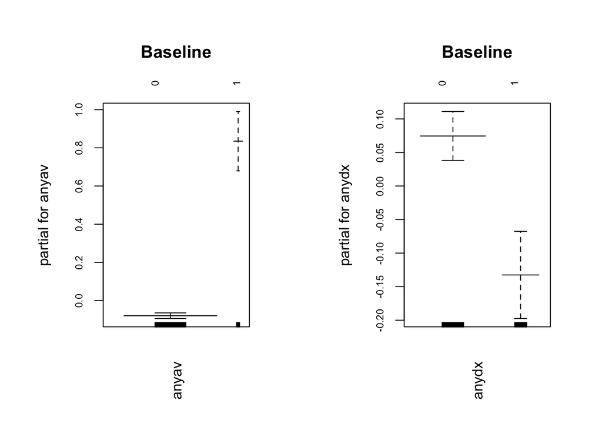

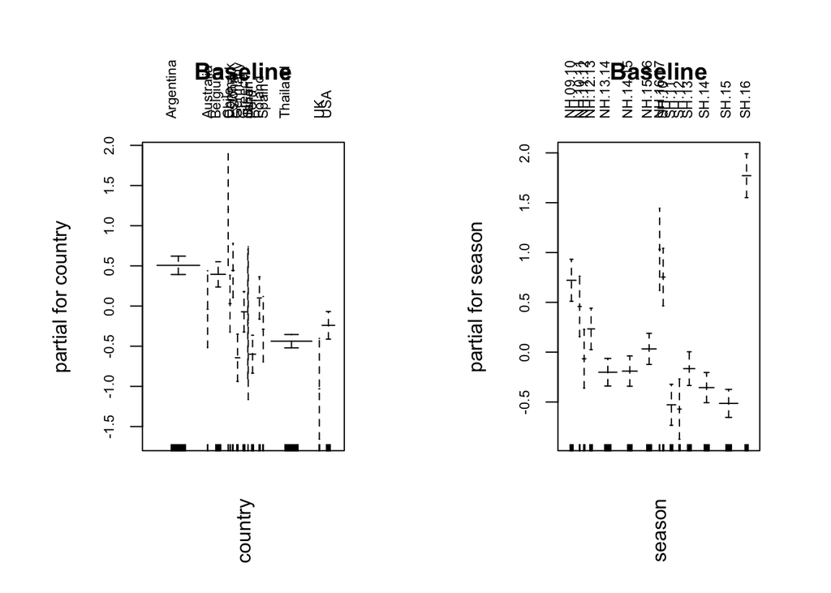

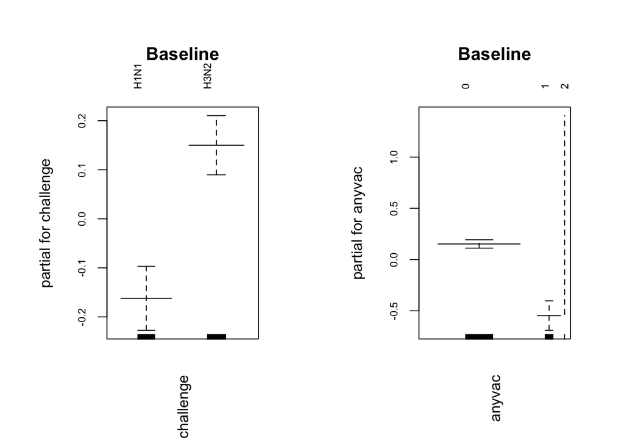

```r
## Plot the fits for each model side by side
par(mfrow = c(1, 2), las = 3, mar = c(6, 6, 6, 3), cex.axis = .7)
library(gam)
plot.gam(fit0, se = T, col = 'darkslateblue', main = 'Baseline')
```

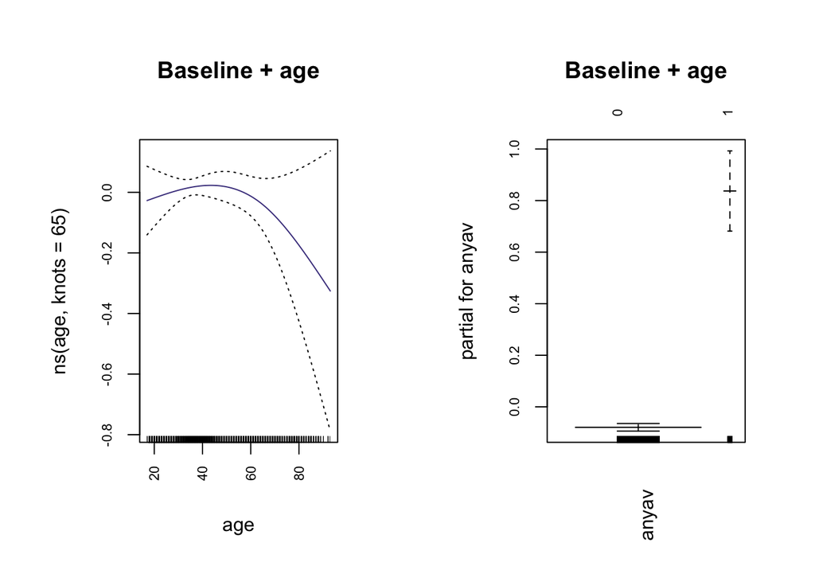

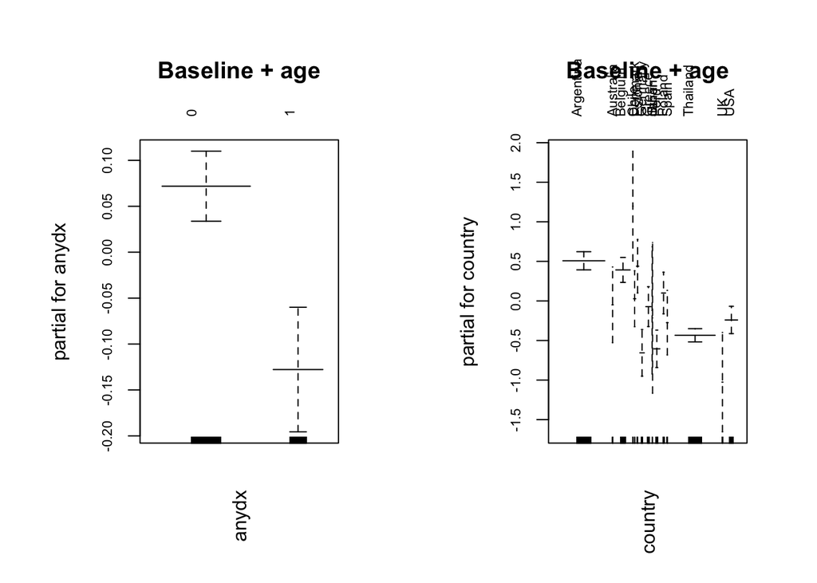

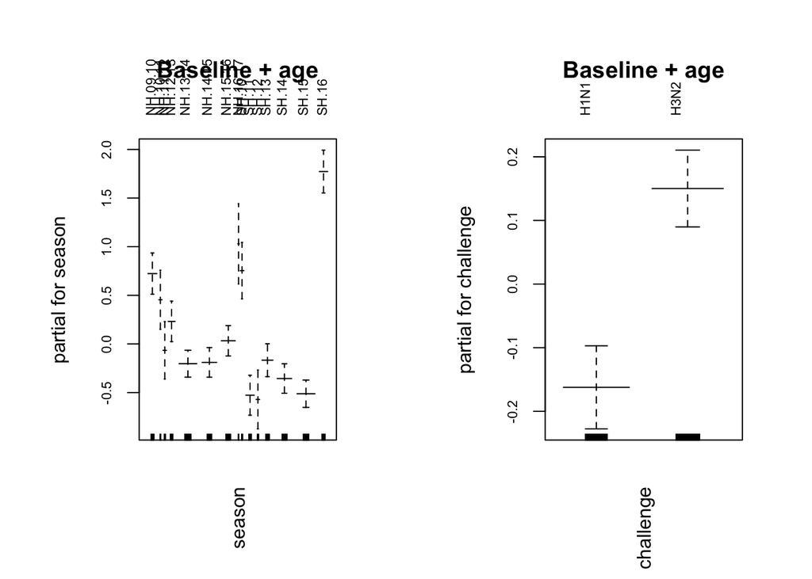

```r
plot.gam(fit1, se = T, col = 'darkslateblue', main = 'Baseline + age')
```

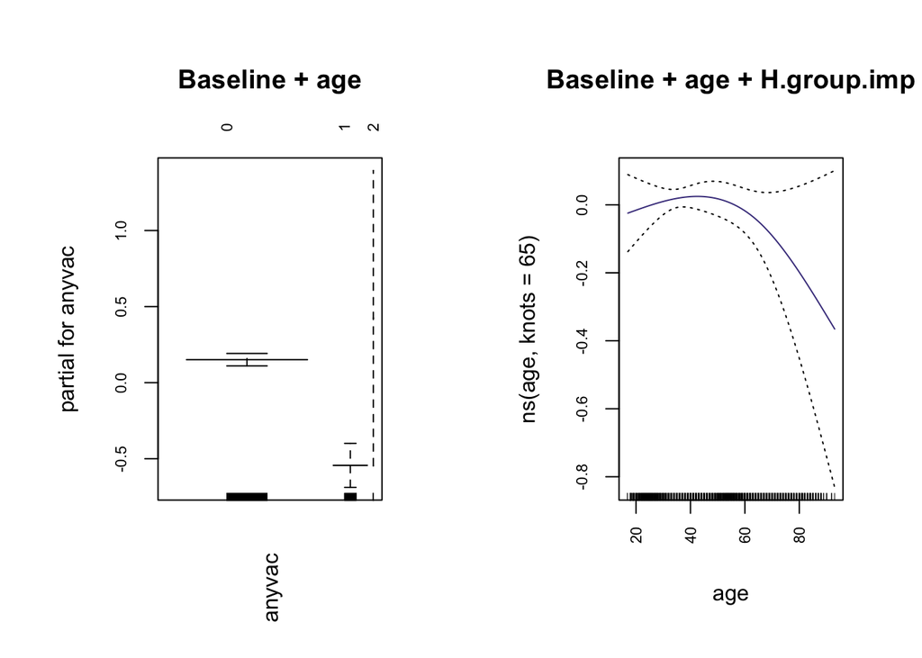

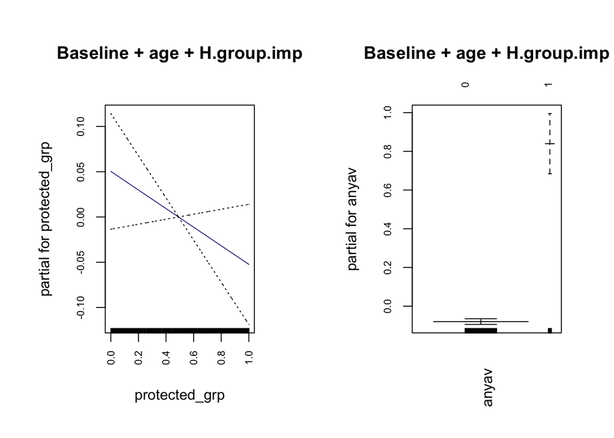

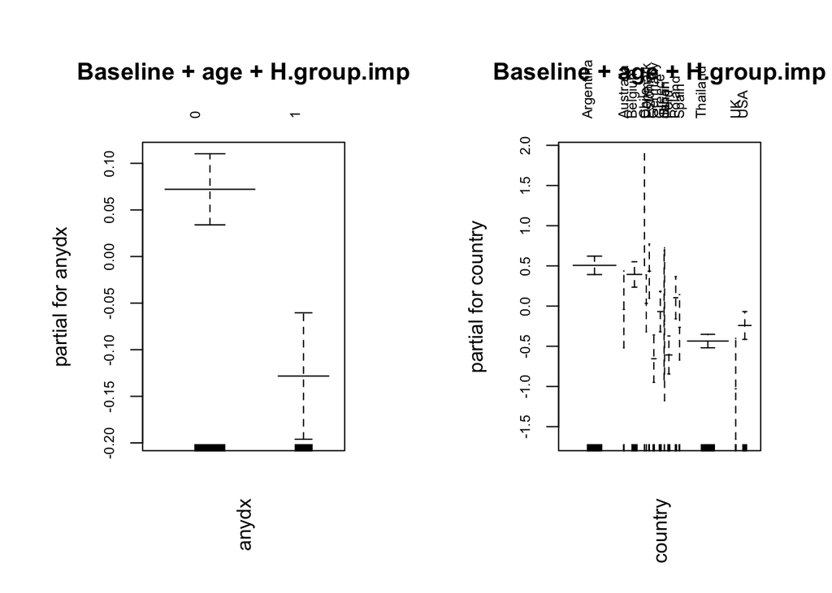

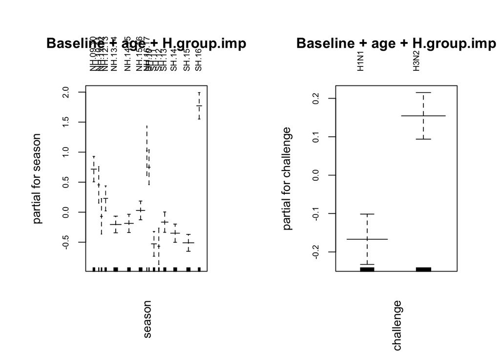

```r
plot.gam(fit2, se = T, col = 'darkslateblue', main = 'Baseline + age + H.group.imp')
```

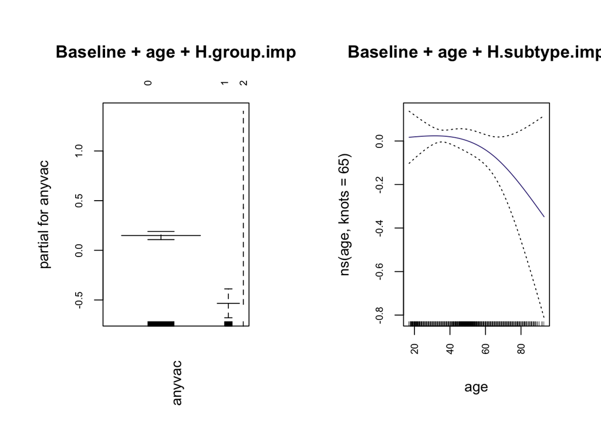

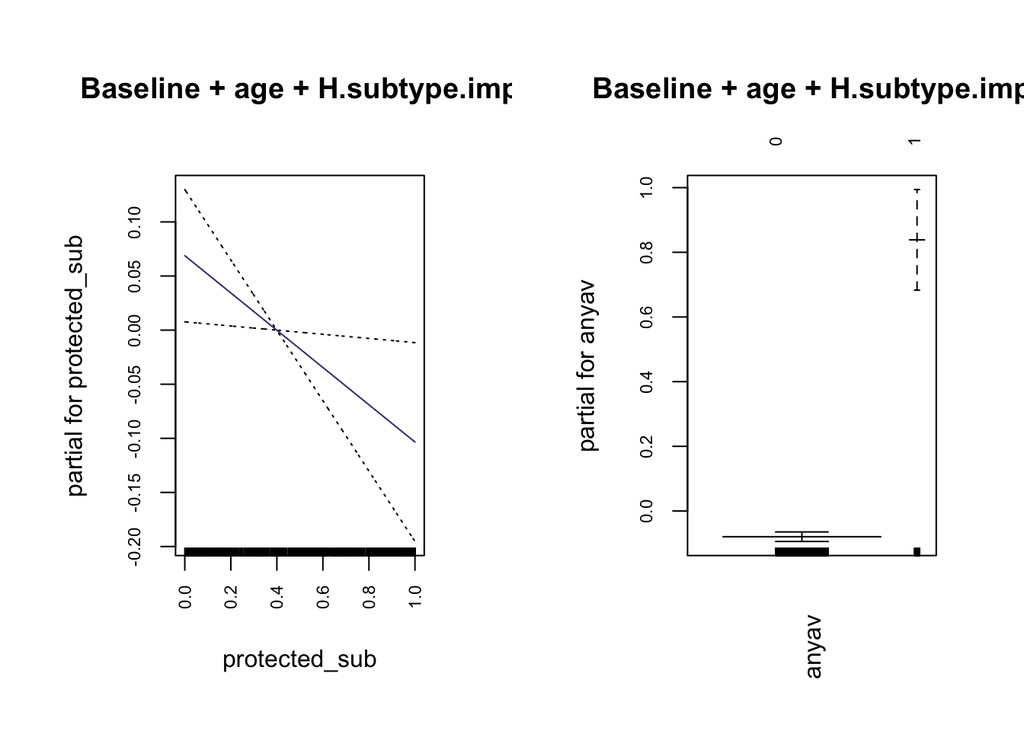

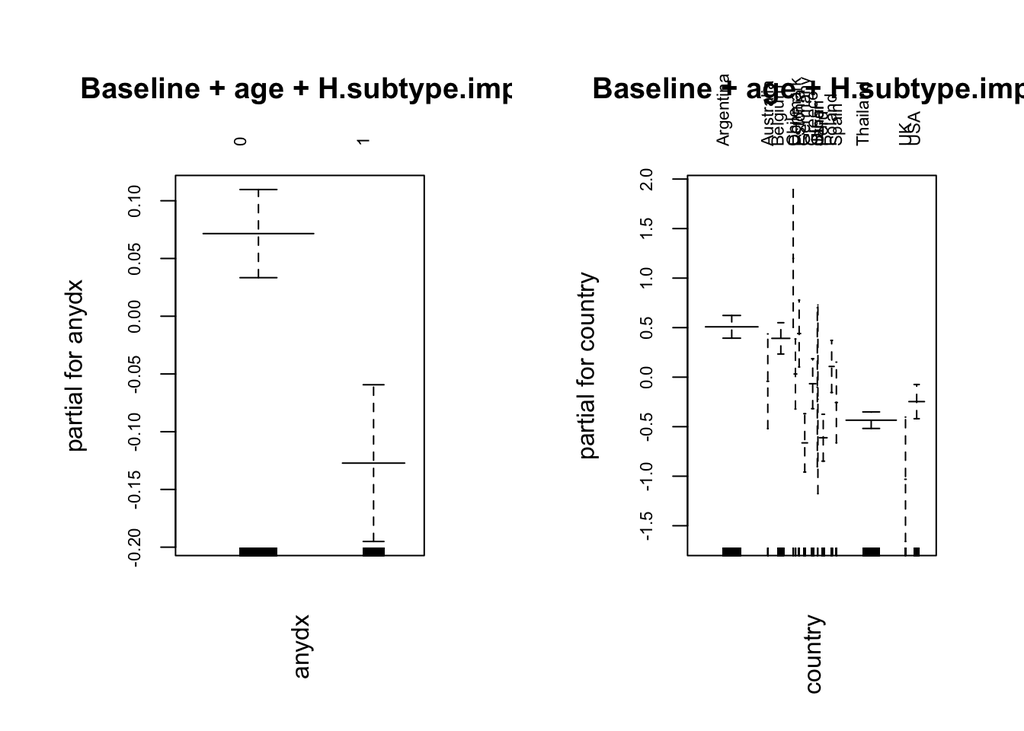

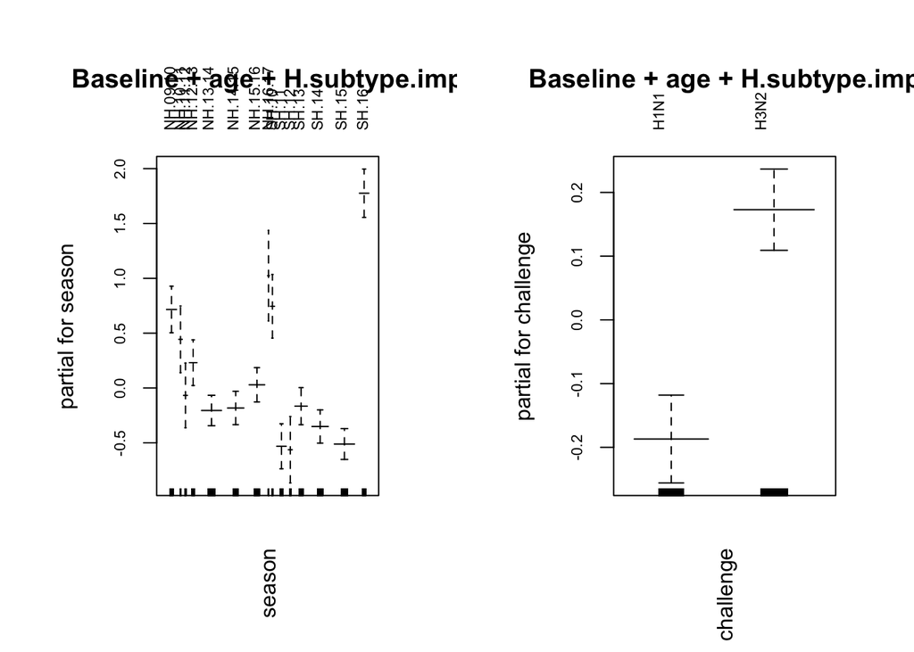

```r
plot.gam(fit3, se = T, col = 'darkslateblue', main = 'Baseline + age + H.subtype.imp')
```

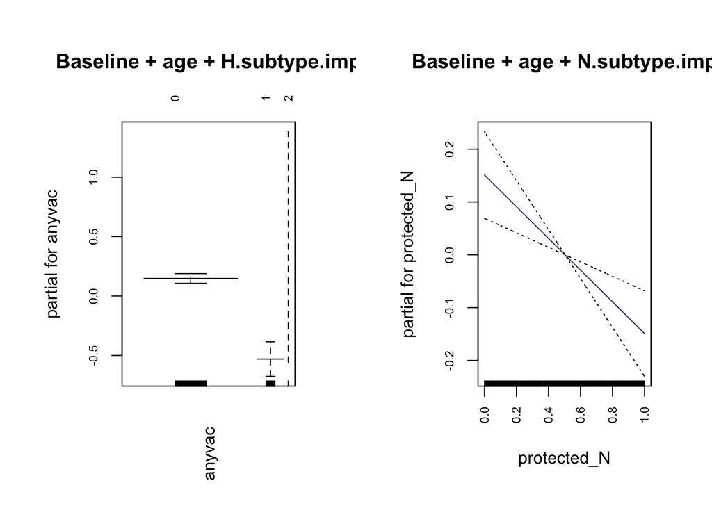

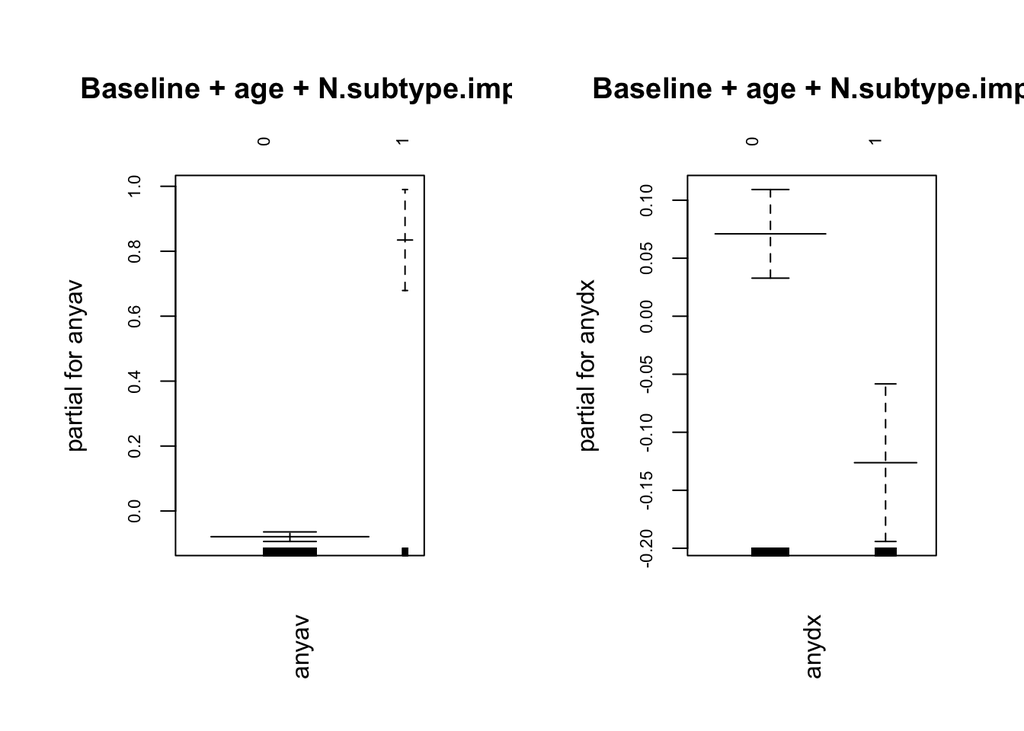

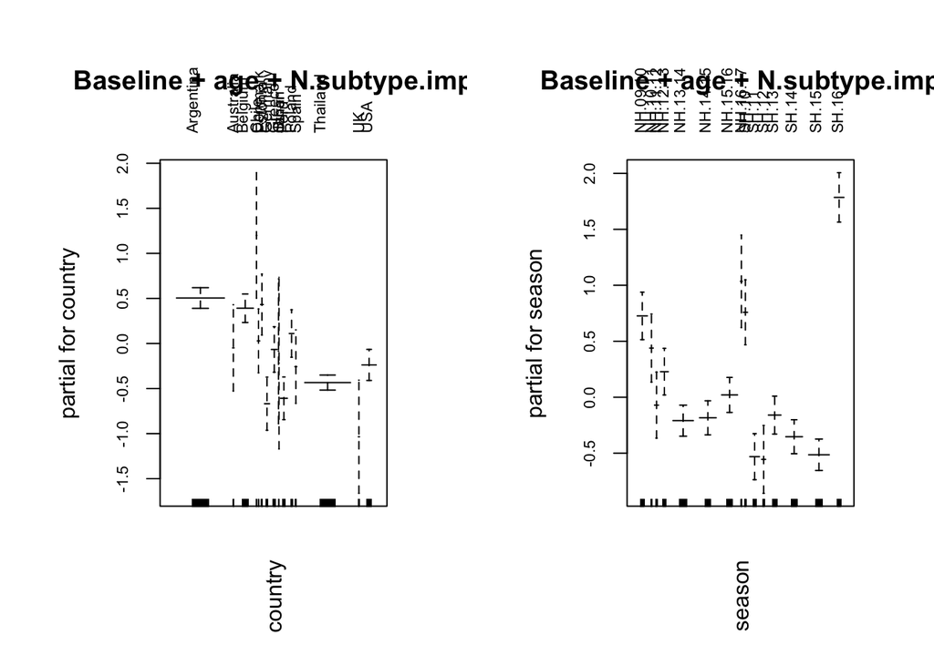

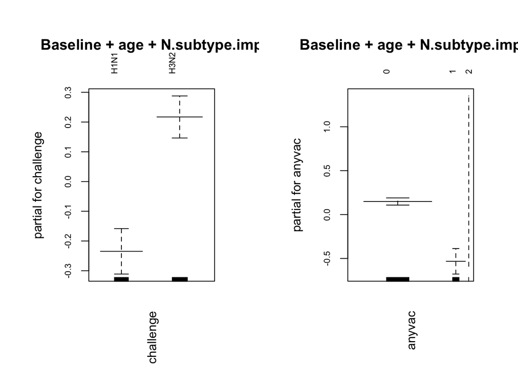

```r
plot.gam(fit4, se = T, col = 'darkslateblue', main = 'Baseline + age + N.subtype.imp')
```

```r
pdf('002Incidence_constrained.pdf')
plot.gam(fit2, se = T, col = 'darkslateblue', main = 'Baseline + age + imp')
dev.off()
```

[figure not shown]

```r
## Test performance on test data
# Predict probs for each patient
probs0 = predict(fit0, newdata = test, type = 'response')
probs1 = predict(fit1, newdata = test, type = 'response')
probs2 = predict(fit2, newdata = test, type = 'response')
probs3 = predict(fit3, newdata = test, type = 'response')
probs4 = predict(fit4, newdata = test, type = 'response')

# Create a predict object
pr0 = prediction(probs0, test$infected)
pr1 = prediction(probs1, test$infected)
pr2 = prediction(probs2, test$infected)
pr3 = prediction(probs3, test$infected)
pr4 = prediction(probs4, test$infected)

# Assess tp and fp
prf0 = performance(pr0, measure = 'tpr', x.measure = 'fpr')
prf1 = performance(pr1, measure = 'tpr', x.measure = 'fpr')
prf2 = performance(pr2, measure = 'tpr', x.measure = 'fpr')
prf3 = performance(pr3, measure = 'tpr', x.measure = 'fpr')
prf4 = performance(pr4, measure = 'tpr', x.measure = 'fpr')

# Calculate AUCs
auc = sapply(list(pr0, pr1, pr2, pr3, pr4), FUN = function(xx){aa = performance(xx, measure = 'auc')
                                                                      round(aa@y.values[[1]], 3) })

# Plot AUC
par(mfrow = c(1,1))
```

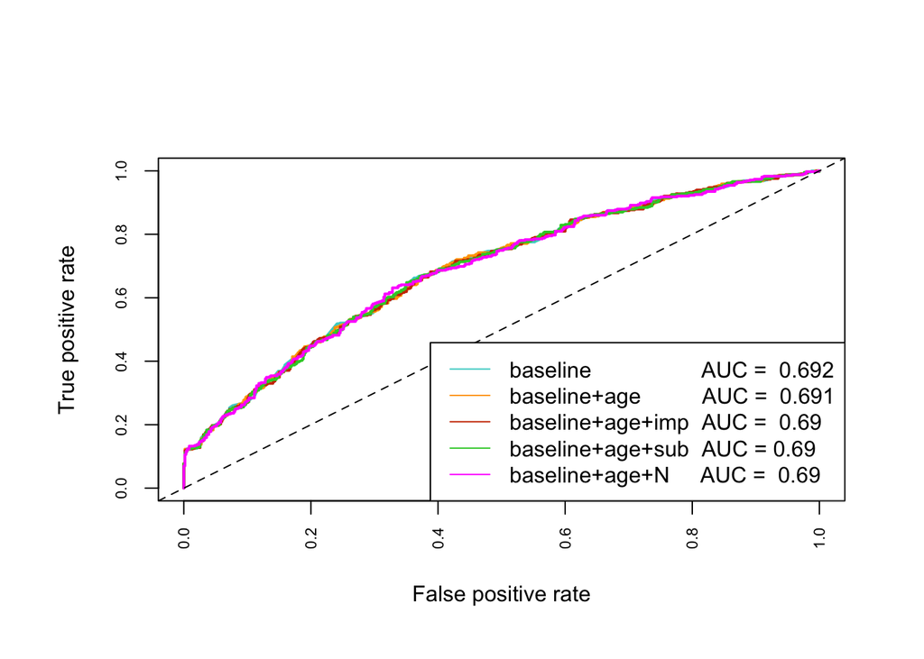

```r
plot(prf0, lwd = 2, col = cols[3])
plot(prf1, col = cols[2], add = TRUE, lwd = 2)
plot(prf2, col = cols[1], add = TRUE, lwd = 2)
plot(prf3, col = 'limegreen', add = TRUE, lwd = 2)
plot(prf4, col = 'magenta', add = TRUE, lwd = 2)
abline(a = 0, b = 1, lty = 2)
legend('bottomright', paste(c('baseline                  AUC = ', 'baseline+age          AUC = ', 'baseline+age+imp  AUC = ', 'baseline+age+sub  AUC =', 'baseline+age+N     AUC = '), auc), col = c(cols[3:1], 'limegreen', 'magenta'),  lty = 1)
```

```r
pdf('002Incidence_AUC_constrained.pdf')
par(lwd = 3.5, cex = 1.5, cex.axis = 1.5, cex.lab = 1.5)
# Plot AUC
par(mfrow = c(1,1))
plot(prf0, lwd = 2, col = cols[3])
plot(prf1, col = cols[2], add = TRUE, lwd = 2)
plot(prf2, col = cols[1], add = TRUE, lwd = 2)
plot(prf3, col = 'limegreen', add = TRUE, lwd = 2)
plot(prf4, col = 'magenta', add = TRUE, lwd = 2)
abline(a = 0, b = 1, lty = 2)
legend('bottomright', paste(c('baseline                  AUC = ', 'baseline+age          AUC = ', 'baseline+age+imp  AUC = ', 'baseline+age+sub  AUC =', 'baseline+age+N     AUC = '), auc), col = c(cols[3:1], 'limegreen', 'magenta'),  lty = 1)
dev.off()
```

```r
# Calculate AUC for test data
AIC = c(fit0$aic, fit1$aic, fit2$aic, fit3$aic, fit4$aic); names(AIC) =  c('baseline', 'baseline+age', 'baseline+age+imp', 'baseline+age+sub', 'baseline+age+N')
del.AIC = sort(AIC - min(AIC))
del.AIC
```

```
##   baseline+age+N baseline+age+sub         baseline baseline+age+imp
##         0.000000         8.600459         9.705366        11.208454
##     baseline+age
##        11.696195
```

```r
load('master.AIC.table.constrained.RData')
master.AIC.table['002Incidence', c('baseline', 'baseline+age', 'baseline+age+imp', 'baseline+age+sub', 'baseline+age+N')] = AIC - min(AIC)
save(master.AIC.table, file = 'master.AIC.table.constrained.RData')
rm(master.AIC.table)
```